# Research

# Abstract

This study examined whether parental ASD family history, sex, ethnicity, age, and neonatal jaundice are associated with ASD-like behavioral traits in 1,054 toddlers from the Q-Chat-10 dataset. Logistic regression models were used to evaluate four questions: demographic moderation of family history effects, item-level associations, the interaction between family history and age, and the interaction between family history and jaundice. Sex showed a consistent association, with boys displaying higher odds of ASD-like traits, and ethnicity showed a modest effect, with children in the “Other” category having lower odds. Jaundice was also modestly associated with increased ASD-like traits. In contrast, parental ASD family history showed weak or non-significant associations in most models, likely due to measurement limitations in the dataset, including a screening-based outcome and a coarse family history variable. Overall, demographic and developmental factors demonstrated clearer associations than parental history, underscoring the need for more precise familial and clinical information in future research.

# 1. Introduction

## 1.1. Background and Motivation

Autism Spectrum Disorder (ASD) is a neurodevelopmental condition characterized by a range of difficulties in social communication, behavioral flexibility, and sensory processing, and it is understood to arise from a combination of genetic and environmental factors (Lord et al., 2020). Recent studies report that the heritability of ASD is approximately 70 to 80 percent (Bai et al., 2019), and that it occurs more frequently in boys (Le Couteur and Szatmari, 2015). One of the strongest pieces of evidence for the genetic basis of ASD comes from twin studies. Monozygotic twins show concordance rates of about 76 percent, whereas dizygotic twins show concordance rates that are close to zero (Tick et al., 2016). This pronounced difference indicates that genetic factors contribute substantially to ASD liability. However, even with high heritability, the extent to which this genetic risk manifests as ASD-related traits may differ depending on developmental and environmental contexts, including sex, race, and age. In fact, ASD shows variation in diagnostic likelihood not only by sex but also across racial and ethnic groups (Mandell et al., 2009; Zaroff and Uhm, 2012), and minority group children have been reported to experience delayed or under-diagnosis even when early behavioral signs of ASD are present (Jo et al., 2015). These findings highlight the importance of understanding how parental family history of ASD as a genetic risk factor interacts with demographic characteristics.

These prior studies show that ASD has a complex set of characteristics that cannot be explained by a single cause, and that genetic risk exists but may not manifest uniformly across all children. Various factors such as sex, race or ethnicity, developmental stage, and birth-related characteristics may influence the expression and interpretation of early risk indicators. The present study builds on this perspective and uses Q-Chat-10 data to explore how parental family history of ASD, as a proxy for genetic risk, is reflected in ASD-related traits together with the child’s sex, race, age, and history of neonatal jaundice. Specifically, the study examines whether children with a family history of ASD show certain behavioral patterns more frequently, whether this influence differs across sex or racial groups, and whether the expression of these traits varies by developmental stage. Through this analysis, the study aims to deepen understanding of the complex structure of ASD risk.

## 1.2. Dataset Description

In the present study, we used the Q-Chat-10 dataset from the [*Autism Dataset for Toddlers*](https://www.kaggle.com/datasets/vaishnavisirigiri/autism-dataset-for-toddlers) published on Kaggle (provided by Vaishnavi Sirigiri). This dataset includes behavioral ASD risk screening data for a total of 1,054 toddlers and was developed to support the creation of simple and accessible behavior-based early ASD risk detection models that address delayed diagnosis and the high cost of clinical assessment. Because this dataset contains both behavioral ASD risk indicators and diverse background information, including sex, race, family history, and birth-related factors, it is well suited for exploratory analyses of how behavioral markers interact with demographic and environmental characteristics to shape ASD-like traits. The variables are as follows:

- Behavioral items (A1–A10): Binary variables representing the ten items of the Q-Chat-10.
  - For A1–A9, responses of Sometimes / Rarely / Never were coded as 1
  - For A10, responses of Always / Usually / Sometimes were coded as 1
- Total score (Qchat.10.Score): Calculated as the sum of A1–A10 and generally interpreted such that a score above 3 indicates a potential presence of ASD traits.
- Binary classification (Class.ASD.Traits): An indicator of ASD-like behavioral traits coded as “Yes” when Qchat.10.Score ≥ 4. This variable reflects behavioral risk screening rather than clinical diagnosis.
- Demographic information: Sex, Ethnicity, and Age_Mons (age in months).
- Family history (Family_mem_with_ASD): A variable indicating whether a parent or family member has a history of ASD, serving as a simple proxy for genetic risk.
- Birth-related factor (Jaundice): An indicator of neonatal jaundice, which can be used as a nonshared environmental or perinatal factor.
- Respondent information (who.completed.the.test): Identifies who completed the questionnaire (e.g., parent or caregiver).

The code below provides a brief overview of the structure of the dataset.

```r
library(tidyverse)
library(broom)
library(ggplot2)
library(patchwork)
library(FactoMineR)
library(factoextra)
library(pheatmap)

nrow(df)
```

```
[1] 1054
```

```r
head(df)
```

```
  Case_No A1 A2 A3 A4 A5 A6 A7 A8 A9 A10 Age_Mons Qchat.10.Score Sex
1       1  0  0  0  0  0  0  1  1  0   1       28              3   f
2       2  1  1  0  0  0  1  1  0  0   0       36              4   m
3       3  1  0  0  0  0  0  1  1  0   1       36              4   m
4       4  1  1  1  1  1  1  1  1  1   1       24             10   m
5       5  1  1  0  1  1  1  1  1  1   1       20              9   f
6       6  1  1  0  0  1  1  1  1  1   1       21              8   m
       Ethnicity Jaundice Family_mem_with_ASD Who.completed.the.test
1 middle eastern      yes                  no          family member
2 White European      yes                  no          family member
3 middle eastern      yes                  no          family member
4       Hispanic       no                  no          family member
5 White European       no                 yes          family member
6          black       no                  no          family member
  Class.ASD.Traits.
1                No
2               Yes
3               Yes
4               Yes
5               Yes
6               Yes
```

```r
plot_pie <- function(data, var, title) {

  df_plot <- data %>%
    count({{ var }}) %>%
    mutate(
      pct = n / sum(n) * 100,
      legend_label = paste0({{ var }}, " (", round(pct, 1), "%)")
    )

  ggplot(df_plot, aes(x = "", y = pct, fill = legend_label)) +
    geom_col(width = 1) +
    coord_polar("y", start = 0) +
    labs(title = title, x = NULL, y = NULL, fill = as_label(enquo(var))) +
    theme_void() +
    theme(
      legend.position = "right",
      plot.title = element_text(hjust = 0.5, size = 16, face = "bold")
    )
}
```

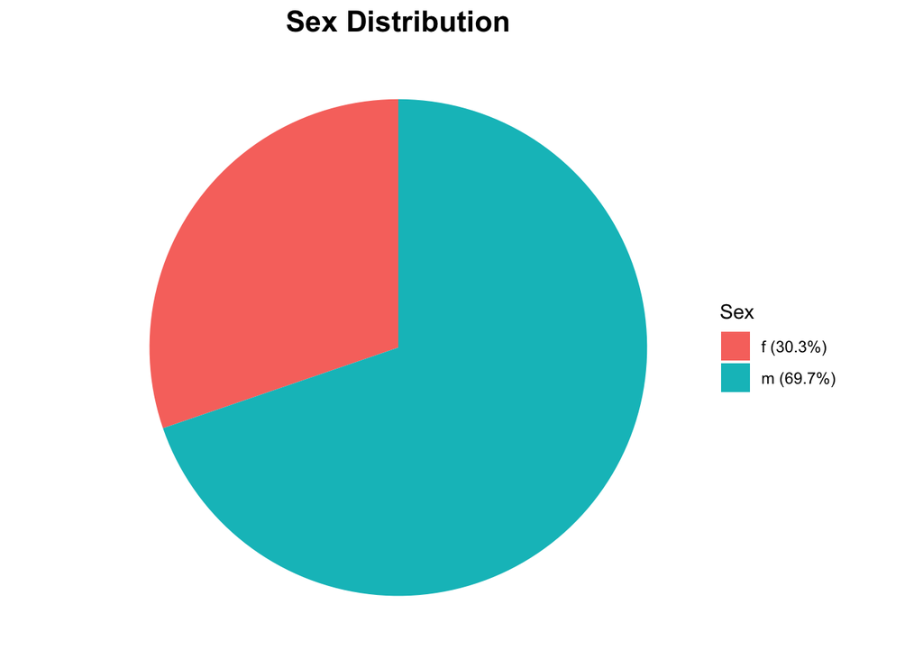

```r
plot_pie(df, Sex, "Sex Distribution")
```

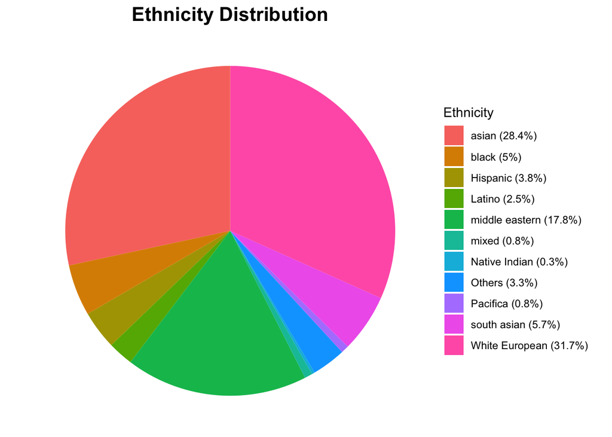

```r
plot_pie(df, Ethnicity, "Ethnicity Distribution")
```

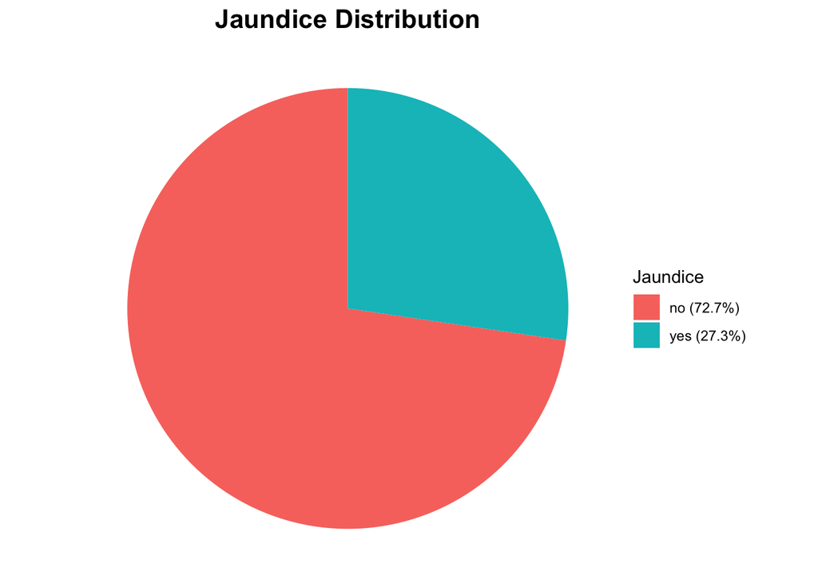

```r
plot_pie(df, Jaundice, "Jaundice Distribution")
```

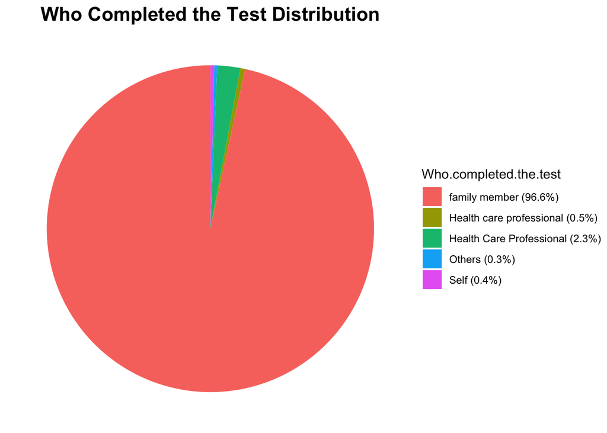

```r
plot_pie(df, Who.completed.the.test, "Who Completed the Test Distribution")
```

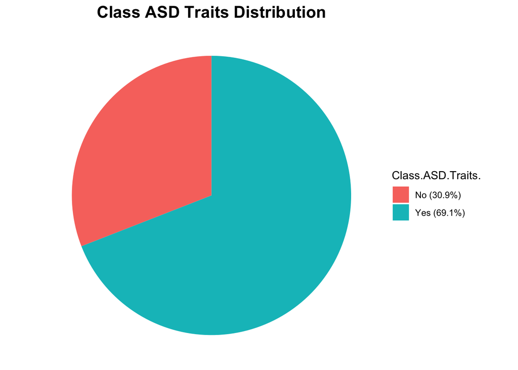

```r
plot_pie(df, Class.ASD.Traits., "Class ASD Traits Distribution")
```

## 1.3. Research Questions

In this study, we address the following four research questions.

1. Does the level of ASD risk differ by sex or ethnicity among children with a parental family history of ASD?
   - Children with a parental history of ASD are known to be more likely to show ASD traits (autistic tendency scores). However, there is limited research on whether this genetic influence operates uniformly across all children, or whether it differs by sex (male/female) or ethnicity group. Therefore, by examining interactions such as family history × sex and family history × ethnicity, we aim to explore whether genetic effects are stronger in specific subgroups.
2. Do children with a parental family history of ASD show higher problem scores on specific behavioral items (A1–A10)?
   - ASD risk is not a single score but is composed of multiple behavioral characteristics (A1–A10). When there is a parental history of ASD, we analyze whether children exhibit stronger risk patterns on particular items. The final results will be visualized using tools such as heatmaps and PCA to explore differences in behavioral patterns.
3. Does the association between parental ASD family history and ASD traits vary according to the child’s age in months (Age_Mons)?
   - The expression of ASD traits may differ across developmental stages in toddlers. Therefore, even when the same family history is present, we explore whether the association with ASD tendency scores varies between younger and older children. Specifically, we analyze age-related differences in effects using the interaction between family history and Age_Mons, treating Age_Mons either as a continuous variable or as a low-age versus high-age grouping variable.
4. What patterns are observed for simple nonshared environmental effects, including jaundice?
   - Although causal relationships cannot be inferred, we explore whether jaundice is independently associated with ASD traits, or whether it further amplifies risk among children with a parental family history of ASD, when considering family history and jaundice status simultaneously.

# 2. Methodology

## 2.1. Logistic Regression Models

For all research questions, we use logistic regression models in which the dependent variable is binary. The general form of the model is:

$$logit{P(ASD traits = 1)} = \beta_0 + \beta X + Interaction terms$$

This framework allows us to examine how parental ASD family history relates to ASD traits, both directly and through interactions with demographic or environmental factors.

### Model 1A - Family ASD x Sex

This model evaluates whether the association between parental ASD history and ASD traits differs by the child’s sex.

### Model 1B - Family ASD x Ethnicity

This model examines whether the effect of parental ASD family history varies across racial and ethnic groups.

$$\begin{aligned}
\text{logit } P(\text{ASD traits} = 1)
&= \beta_0 + \beta_1 \text{FamilyASD} + \beta_2 \text{Ethnicity}
+ \beta_3 (\text{FamilyASD} \times \text{Ethnicity}) \\
&\quad + \beta_4 \text{Sex} + \beta_5 \text{AgeMons} + \beta_6 \text{Jaundice}
\end{aligned}$$

This allows us to assess potential demographic disparities in how genetic risk manifests behaviorally.

### Model 2 - Item-Level Logistic Regressions

To understand how parental ASD history relates to specific behavioral domains, we fit separate logistic regression models for each Q-Chat-10 item.

For all Items $A_i (i = 1, 2, ..., 10)$

$$\begin{aligned}
\text{logit } P(A_i = 1)
&= \beta_0 + \beta_1 \text{FamilyASD} + \beta_2 \text{Sex}
+ \beta_3 \text{Ethnicity} \\
&\quad + \beta_4 \text{AgeMons} + \beta_5 \text{Jaundice}
\end{aligned}$$

Interaction terms are not used here because the goal is to identify global behavioral tendencies associated with family history rather than to model effect modification.

### Model 3 - Family ASD x Age_Mons

This model tests whether age moderates the relationship between family history and ASD traits.

$$\begin{aligned}
\text{logit } P(\text{ASD traits} = 1)
&= \beta_0 + \beta_1 \text{FamilyASD} + \beta_2 \text{AgeMons}
+ \beta_3 (\text{FamilyASD} \times \text{AgeMons}) \\
&\quad + \beta_4 \text{Sex} + \beta_5 \text{Ethnicity} + \beta_6 \text{Jaundice}
\end{aligned}$$

This approach captures potential developmental differences in the expression of ASD-related behaviors.

### Model 4 - Family ASD x Jaundice

This model evaluates whether neonatal jaundice modifies the association between family history and ASD traits.

$$\begin{aligned}
\text{logit } P(\text{ASD traits} = 1)
&= \beta_0 + \beta_1 \text{FamilyASD} + \beta_2 \text{Jaundice}
+ \beta_3 (\text{FamilyASD} \times \text{Jaundice}) \\
&\quad + \beta_4 \text{Sex} + \beta_5 \text{Ethnicity} + \beta_6 \text{AgeMons}
\end{aligned}$$

This enables exploratory assessment of a possible nonshared environmental factor and its interaction with genetic risk.

## 2.2. Principal Component Analysis (PCA)

Principal Component Analysis (PCA) is a dimensionality reduction method that converts correlated variables into a smaller set of uncorrelated components that capture the main axes of variation. Because the ten behavioral items are expected to co-occur, PCA provides a concise way to characterize their joint structure and identify underlying behavioral dimensions. By mapping individuals onto the first two principal components, we can visualize broad patterns in these behaviors and assess whether children with a parental ASD family history show discernible differences compared to those without such history. This approach allows us to detect group-level distinctions in overall behavioral profiles that may not be apparent from item-by-item analyses.

## 2.3. Data Cleansing

Before conducting the regression analyses, we performed basic data cleansing to ensure that all variables were coded in formats appropriate for statistical modeling. The following code converts key categorical variables into factors with explicitly defined levels, standardizes the coding of binary variables, and inspects the distribution of each category. In preliminary models, some ethnicity categories had very small cell counts and contributed to quasi-complete separation in logistic regression, particularly when interaction terms with family ASD history were included. To mitigate this issue and obtain stable estimates, we further collapsed ethnicity into two groups (White vs Other) for the regression analyses.

```r
df$Class.ASD.Traits      <- factor(df$Class.ASD.Traits, levels = c("No", "Yes"))
df$Family_mem_with_ASD   <- factor(df$Family_mem_with_ASD, levels = c("no", "yes"))
df$Jaundice              <- factor(df$Jaundice, levels = c("no", "yes"))
df$Sex                   <- factor(df$Sex)
df$Ethnicity             <- factor(df$Ethnicity)
df$Age_Mons              <- as.numeric(df$Age_Mons)

lapply(
  df[, c("Class.ASD.Traits", "Family_mem_with_ASD", "Jaundice",
         "Sex", "Ethnicity")],
  table,
  useNA = "ifany"
)
```

```
$Class.ASD.Traits

 No Yes
326 728

$Family_mem_with_ASD

 no yes
884 170

$Jaundice

 no yes
766 288

$Sex

  f   m
319 735

$Ethnicity

         asian          black       Hispanic         Latino middle eastern
           299             53             40             26            188
         mixed  Native Indian         Others       Pacifica    south asian
             8              3             35              8             60
White European
           334
```

```r
df_rq1 <- df %>%
  mutate(
    Class_ASD  = factor(Class.ASD.Traits, levels = c("No", "Yes")),
    Family_ASD = factor(Family_mem_with_ASD, levels = c("no", "yes")),
    Sex        = factor(Sex),
    Ethnicity  = factor(Ethnicity),
    Age_Mons   = as.numeric(Age_Mons)
  ) %>%
  filter(
    !is.na(Class_ASD),
    !is.na(Family_ASD),
    !is.na(Sex),
    !is.na(Ethnicity),
    !is.na(Age_Mons)
  ) %>%
  mutate(
    Ethnicity_collapsed = ifelse(grepl("White", Ethnicity), "White", "Other"),
    Ethnicity_collapsed = factor(Ethnicity_collapsed, levels = c("White", "Other"))
  )
```

# 3. Results

## 3.1. Results for RQ1

```r
library(dplyr)
library(forcats)
library(logistf)
library(knitr)

model_sex <- glm(
  Class_ASD ~ Family_ASD * Sex + Age_Mons + Ethnicity_collapsed,
  data   = df_rq1,
  family = binomial
)
```

```r
tbl_sex <- tidy(
  model_sex,
  exponentiate = TRUE,
  conf.int    = TRUE
) %>%

  mutate(term = case_when(
    term == "(Intercept)"               ~ "Intercept",
    term == "Family_ASDyes"            ~ "Family ASD history (yes vs no)",
    term == "Sexmale"                  ~ "Sex (male vs female)",
    grepl("^Ethnicity_collapsed", term)~ gsub("Ethnicity_collapsed", "Ethnicity: ", term),
    term == "Age_Mons"                 ~ "Age (months)",
    term == "Family_ASDyes:Sexmale"    ~ "Family ASD × Sex interaction",
    TRUE                               ~ term
  )) %>%
  rename(
    OR        = estimate,
    `CI low`  = conf.low,
    `CI high` = conf.high,
    `p-value` = p.value
  )
```

```r
kable(
  tbl_sex,
  digits  = 3,
  caption = "Logistic regression of ASD traits on family ASD history, sex, age, and ethnicity"
)
```

Logistic regression of ASD traits on family ASD history, sex, age, and ethnicity

| term | OR | std.error | statistic | p-value | CI low | CI high |
| --- | --- | --- | --- | --- | --- | --- |
| Intercept | 1.496 | 0.271 | 1.486 | 0.137 | 0.882 | 2.554 |
| Family ASD history (yes vs no) | 0.610 | 0.343 | -1.441 | 0.150 | 0.311 | 1.203 |
| Sexm | 1.556 | 0.156 | 2.834 | 0.005 | 1.145 | 2.110 |
| Age (months) | 1.016 | 0.008 | 1.889 | 0.059 | 0.999 | 1.033 |
| Ethnicity: Other | 0.644 | 0.152 | -2.899 | 0.004 | 0.476 | 0.864 |
| Family_ASDyes:Sexm | 1.520 | 0.405 | 1.034 | 0.301 | 0.686 | 3.371 |

In Model 1A, male sex emerged as a significant predictor of ASD traits, with males exhibiting approximately 1.56 times higher odds of being classified as displaying ASD-like behaviors than females. Parental ASD family history did not show a strong independent main effect, and the interaction between family history and sex was not statistically significant, indicating that the influence of family history does not differ substantially between males and females. Age showed a marginal trend toward higher odds of ASD traits with increasing months, although this association did not reach conventional significance. Children categorized in the Other ethnicity group had significantly lower odds of ASD traits compared to White children. Overall, sex and ethnicity were the strongest predictors in the model, whereas the modifying role of family history was not supported.

```r
model_eth <- glm(
  Class_ASD ~ Family_ASD * Ethnicity_collapsed + Sex + Age_Mons + Jaundice,
  data   = df_rq1,
  family = binomial
)

tbl_eth <- tidy(
  model_eth,
  exponentiate = TRUE,   # OR
  conf.int    = TRUE     # 95% CI
) %>%
  mutate(term = case_when(
    term == "(Intercept)"                        ~ "Intercept",
    term == "Family_ASDyes"                     ~ "Family ASD history (yes vs no)",
    term == "Sexmale"                           ~ "Sex (male vs female)",
    grepl("^Ethnicity_collapsed", term)         ~ gsub("Ethnicity_collapsed", "Ethnicity: ", term),
    grepl("Family_ASDyes:Ethnicity_collapsed", term) ~ gsub("Family_ASDyes:Ethnicity_collapsed",
                                                            "Interaction: Family ASD × Ethnicity: ", term),
    term == "Age_Mons"                          ~ "Age (months)",
    term == "Jaundiceyes"                       ~ "Jaundice (yes vs no)",
    TRUE                                        ~ term
  )) %>%
  rename(
    OR        = estimate,
    `CI low`  = conf.low,
    `CI high` = conf.high,
    `p-value` = p.value
  )

kable(
  tbl_eth,
  digits  = 3,
  caption = "Logistic regression of ASD traits on family ASD history, ethnicity, sex, age, and jaundice"
)
```

Logistic regression of ASD traits on family ASD history, ethnicity, sex, age, and jaundice

| term | OR | std.error | statistic | p-value | CI low | CI high |
| --- | --- | --- | --- | --- | --- | --- |
| Intercept | 1.310 | 0.281 | 0.962 | 0.336 | 0.758 | 2.281 |
| Family ASD history (yes vs no) | 0.716 | 0.297 | -1.128 | 0.259 | 0.403 | 1.297 |
| Ethnicity: Other | 0.652 | 0.171 | -2.500 | 0.012 | 0.463 | 0.908 |
| Sexm | 1.633 | 0.144 | 3.394 | 0.001 | 1.229 | 2.166 |
| Age (months) | 1.017 | 0.008 | 1.940 | 0.052 | 1.000 | 1.034 |
| Jaundice (yes vs no) | 1.389 | 0.159 | 2.061 | 0.039 | 1.020 | 1.905 |
| Interaction: Family ASD × Ethnicity: Other | 1.208 | 0.378 | 0.501 | 0.616 | 0.573 | 2.528 |

In Model 1B, ethnicity and sex emerged as significant predictors of ASD trait classification. Children in the Other ethnicity group showed significantly lower odds of ASD traits compared to White children, and males exhibited higher odds than females. Age showed a marginal positive association with ASD traits, and jaundice was associated with higher odds, although the interpretation remains exploratory. Parental ASD family history did not have a significant main effect, and the interaction between family history and ethnicity was not significant, indicating that the influence of family history does not differ meaningfully across ethnic groups.

## 3.2. Results for RQ2

```r
item_vars <- paste0("A", 1:10)

models_items <- lapply(item_vars, function(v) {
  glm(
    as.formula(
      paste(v, "~ Family_ASD + Sex + Ethnicity_collapsed + Age_Mons + Jaundice")
    ),
    data   = df_rq1,
    family = binomial
  )
})

names(models_items) <- item_vars
```

```r
tbl_items <- lapply(names(models_items), function(v) {
  tidy(models_items[[v]],
       exponentiate = TRUE,
       conf.int     = TRUE) %>%
    mutate(item = v)
}) %>%
  bind_rows() %>%
  relocate(item, .before = term)

tbl_items_family <- tbl_items %>%
  filter(term == "Family_ASDyes") %>%
  rename(
    OR        = estimate,
    `CI low`  = conf.low,
    `CI high` = conf.high,
    `p-value` = p.value
  )

kable(
  tbl_items_family,
  digits  = 3,
  caption = "Association between parental ASD history and each Q-Chat-10 item (adjusted for sex, ethnicity, age, and jaundice)"
)
```

Association between parental ASD history and each Q-Chat-10 item (adjusted for sex, ethnicity, age, and jaundice)

| item | term | OR | std.error | statistic | p-value | CI low | CI high |
| --- | --- | --- | --- | --- | --- | --- | --- |
| A1 | Family_ASDyes | 1.228 | 0.175 | 1.171 | 0.242 | 0.873 | 1.738 |
| A2 | Family_ASDyes | 1.107 | 0.170 | 0.598 | 0.550 | 0.792 | 1.546 |
| A3 | Family_ASDyes | 1.240 | 0.172 | 1.249 | 0.212 | 0.883 | 1.737 |
| A4 | Family_ASDyes | 0.759 | 0.172 | -1.606 | 0.108 | 0.541 | 1.062 |
| A5 | Family_ASDyes | 0.814 | 0.171 | -1.204 | 0.229 | 0.582 | 1.138 |
| A6 | Family_ASDyes | 1.214 | 0.176 | 1.105 | 0.269 | 0.863 | 1.719 |
| A7 | Family_ASDyes | 0.800 | 0.176 | -1.263 | 0.206 | 0.568 | 1.134 |
| A8 | Family_ASDyes | 0.776 | 0.172 | -1.469 | 0.142 | 0.553 | 1.086 |
| A9 | Family_ASDyes | 0.885 | 0.171 | -0.719 | 0.472 | 0.632 | 1.236 |
| A10 | Family_ASDyes | 1.015 | 0.173 | 0.086 | 0.931 | 0.725 | 1.428 |

Across the ten behavioral items (A1–A10), none of the odds ratios associated with parental ASD history reached statistical significance after adjusting for sex, ethnicity, age, and jaundice. The odds ratios ranged roughly from 0.76 to 1.24, indicating small and inconsistent differences between children with and without an ASD family history.

- For some items (e.g., A1, A3, A6), the OR was slightly above 1, suggesting a weak trend toward higher endorsement among children with a family history.
- For other items (e.g., A4, A5, A7, A8), the OR was below 1, indicating a weak trend in the opposite direction.
- However, all p-values were greater than 0.10, and all confidence intervals crossed 1.0, meaning none of these differences provide statistically reliable evidence of item-specific effects.

Although item-level logistic regressions did not reveal significant associations with parental ASD history, we additionally examined the multivariate item structure using PCA and heatmaps. These exploratory visualizations likewise showed minimal separation between groups, reinforcing the conclusion that family history does not selectively influence specific behavioral indicators.

```r
items <- df_rq1[, paste0("A", 1:10)]

pca_res <- prcomp(items, scale. = TRUE)
summary(pca_res)
```

```
Importance of components:
                          PC1    PC2     PC3     PC4     PC5     PC6     PC7
Standard deviation     1.8994 1.0944 0.93415 0.91420 0.87753 0.79994 0.75919
Proportion of Variance 0.3608 0.1198 0.08726 0.08358 0.07701 0.06399 0.05764
Cumulative Proportion  0.3608 0.4806 0.56782 0.65140 0.72840 0.79239 0.85003
                           PC8     PC9    PC10
Standard deviation     0.74182 0.72779 0.64787
Proportion of Variance 0.05503 0.05297 0.04197
Cumulative Proportion  0.90506 0.95803 1.00000
```

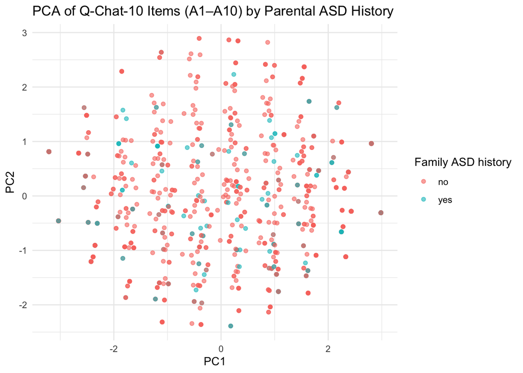

```r
pca_df <- data.frame(
  PC1        = pca_res$x[, 1],
  PC2        = pca_res$x[, 2],
  Family_ASD = df_rq1$Family_ASD
)

ggplot(pca_df, aes(PC1, PC2, color = Family_ASD)) +
  geom_point(alpha = 0.6) +
  theme_minimal() +
  labs(
    title = "PCA of Q-Chat-10 Items (A1–A10) by Parental ASD History",
    x     = "PC1",
    y     = "PC2",
    color = "Family ASD history"
  )
```

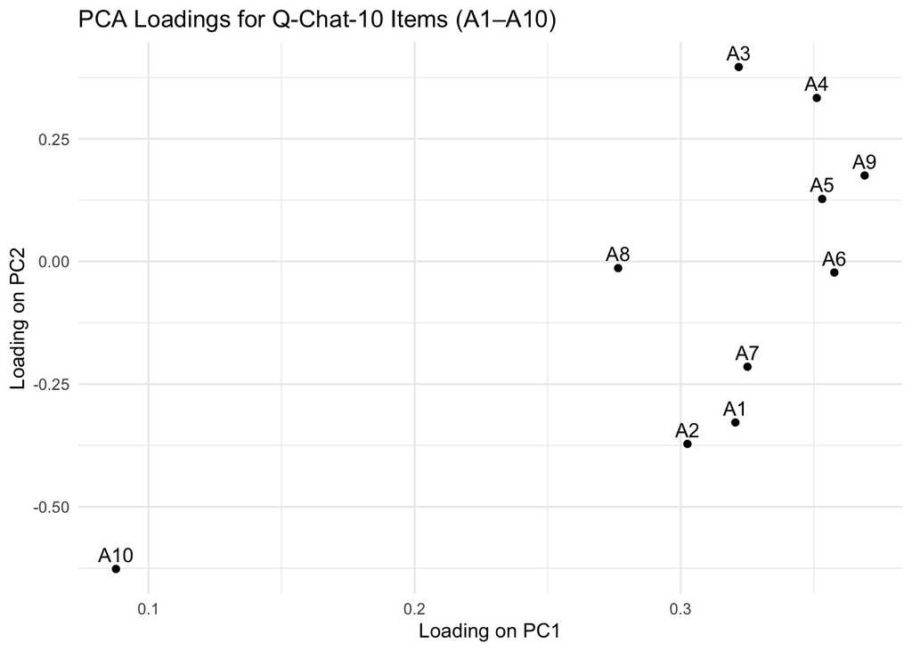

```r
loadings <- data.frame(
  item = rownames(pca_res$rotation),
  PC1  = pca_res$rotation[, 1],
  PC2  = pca_res$rotation[, 2]
)

ggplot(loadings, aes(PC1, PC2, label = item)) +
  geom_point() +
  geom_text(vjust = -0.5) +
  theme_minimal() +
  labs(
    title = "PCA Loadings for Q-Chat-10 Items (A1–A10)",
    x     = "Loading on PC1",
    y     = "Loading on PC2"
  )
```

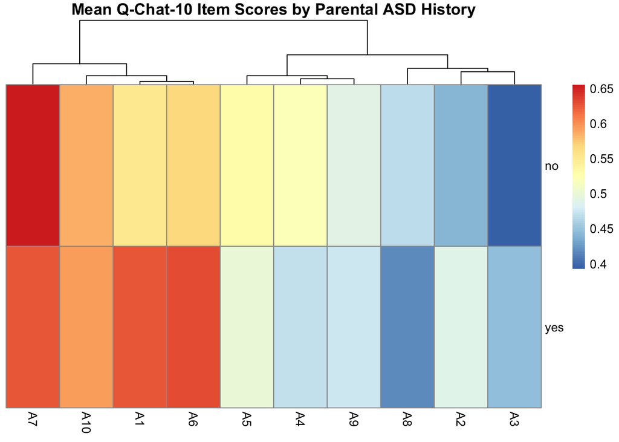

```r
library(pheatmap)
item_means <- aggregate(
  items,
  by   = list(Family_ASD = df_rq1$Family_ASD),
  FUN  = mean
)

rownames(item_means) <- item_means$Family_ASD
item_means$Family_ASD <- NULL

pheatmap(
  item_means,
  cluster_rows = FALSE,
  cluster_cols = TRUE,
  main = "Mean Q-Chat-10 Item Scores by Parental ASD History"
)
```

Across all analyses including item-level logistic regressions, PCA, and heatmap visualizations, there was no evidence that parental ASD family history was associated with specific behavioral patterns on the Q-Chat-10. Children with and without a family history showed nearly identical distributions across individual items, similar positions in the PCA space, and comparable mean item scores. These findings suggest that family history does not selectively influence particular early behavioral indicators measured by the Q-Chat-10.

## 3.3. Results for RQ3

```r
model3_age <- glm(
  Class_ASD ~ Family_ASD * Age_Mons +
    Sex + Ethnicity_collapsed + Jaundice,
  data   = df_rq1,
  family = binomial
)
summary(model3_age)
```

```
Call:
glm(formula = Class_ASD ~ Family_ASD * Age_Mons + Sex + Ethnicity_collapsed +
    Jaundice, family = binomial, data = df_rq1)

Coefficients:
                          Estimate Std. Error z value Pr(>|z|)
(Intercept)               0.035053   0.288428   0.122 0.903270
Family_ASDyes             1.289145   0.716939   1.798 0.072157 .
Age_Mons                  0.024395   0.009189   2.655 0.007931 **
Sexm                      0.484727   0.144592   3.352 0.000801 ***
Ethnicity_collapsedOther -0.396509   0.153057  -2.591 0.009581 **
Jaundiceyes               0.314834   0.159552   1.973 0.048469 *
Family_ASDyes:Age_Mons   -0.052923   0.023994  -2.206 0.027410 *
---
Signif. codes:  0 '***' 0.001 '**' 0.01 '*' 0.05 '.' 0.1 ' ' 1

(Dispersion parameter for binomial family taken to be 1)

    Null deviance: 1303.9  on 1053  degrees of freedom
Residual deviance: 1268.6  on 1047  degrees of freedom
AIC: 1282.6

Number of Fisher Scoring iterations: 4
```

```r
tbl_model3 <- tidy(
  model3_age,
  exponentiate = TRUE,   # OR
  conf.int     = TRUE    # CI
) %>%
  mutate(term = case_when(
    term == "(Intercept)"            ~ "Intercept",
    term == "Family_ASDyes"         ~ "Family ASD history (yes vs no)",
    term == "Age_Mons"              ~ "Age (months)",
    term == "Family_ASDyes:Age_Mons" ~ "Interaction: Family ASD × Age",
    term == "Sexmale"               ~ "Sex (male vs female)",
    grepl("^Ethnicity_collapsed", term) ~ gsub("Ethnicity_collapsed", "Ethnicity: ", term),
    term == "Jaundiceyes"           ~ "Jaundice (yes vs no)",
    TRUE                             ~ term
  )) %>%
  rename(
    OR        = estimate,
    `CI low`  = conf.low,
    `CI high` = conf.high,
    `p-value` = p.value
  )

kable(
  tbl_model3,
  digits  = 3,
  caption = "Model 3: Interaction between family ASD history and age (months)"
)
```

Model 3: Interaction between family ASD history and age (months)

| term | OR | std.error | statistic | p-value | CI low | CI high |
| --- | --- | --- | --- | --- | --- | --- |
| Intercept | 1.036 | 0.288 | 0.122 | 0.903 | 0.590 | 1.829 |
| Family ASD history (yes vs no) | 3.630 | 0.717 | 1.798 | 0.072 | 0.924 | 15.582 |
| Age (months) | 1.025 | 0.009 | 2.655 | 0.008 | 1.006 | 1.043 |
| Sexm | 1.624 | 0.145 | 3.352 | 0.001 | 1.222 | 2.155 |
| Ethnicity: Other | 0.673 | 0.153 | -2.591 | 0.010 | 0.497 | 0.905 |
| Jaundice (yes vs no) | 1.370 | 0.160 | 1.973 | 0.048 | 1.006 | 1.881 |
| Interaction: Family ASD × Age | 0.948 | 0.024 | -2.206 | 0.027 | 0.904 | 0.993 |

Model 3 assessed whether the association between parental ASD history and ASD traits varied across age by including a Family ASD × Age interaction term. The interaction was statistically significant (OR = 0.948, p = 0.027), indicating that the age-related increase in ASD trait endorsement was weaker among children with a parental ASD family history. In other words, although older toddlers generally showed higher odds of ASD-like behaviors, this developmental increase was less pronounced in the family-history group. This suggests that the influence of parental ASD history may be stronger at younger ages and gradually attenuate as children grow. Age, sex, and jaundice also showed independent associations with ASD traits.

## 3.4. Results for RQ4

```r
model4_jaundice <- glm(
  Class_ASD ~ Family_ASD * Jaundice +
    Sex + Ethnicity_collapsed + Age_Mons,
  data   = df_rq1,
  family = binomial
)

summary(model4_jaundice)
```

```
Call:
glm(formula = Class_ASD ~ Family_ASD * Jaundice + Sex + Ethnicity_collapsed +
    Age_Mons, family = binomial, data = df_rq1)

Coefficients:
                           Estimate Std. Error z value Pr(>|z|)
(Intercept)                0.252496   0.274841   0.919 0.358253
Family_ASDyes             -0.314556   0.218003  -1.443 0.149050
Jaundiceyes                0.265634   0.175855   1.511 0.130910
Sexm                       0.487976   0.144376   3.380 0.000725 ***
Ethnicity_collapsedOther  -0.391826   0.152738  -2.565 0.010307 *
Age_Mons                   0.016635   0.008465   1.965 0.049409 *
Family_ASDyes:Jaundiceyes  0.332451   0.407144   0.817 0.414189
---
Signif. codes:  0 '***' 0.001 '**' 0.01 '*' 0.05 '.' 0.1 ' ' 1

(Dispersion parameter for binomial family taken to be 1)

    Null deviance: 1303.9  on 1053  degrees of freedom
Residual deviance: 1272.9  on 1047  degrees of freedom
AIC: 1286.9

Number of Fisher Scoring iterations: 4
```

```r
tbl_model4 <- tidy(
  model4_jaundice,
  exponentiate = TRUE,
  conf.int     = TRUE
) %>%
  mutate(term = case_when(
    term == "(Intercept)"              ~ "Intercept",
    term == "Family_ASDyes"           ~ "Family ASD history (yes vs no)",
    term == "Jaundiceyes"             ~ "Jaundice (yes vs no)",
    term == "Family_ASDyes:Jaundiceyes" ~ "Interaction: Family ASD × Jaundice",
    term == "Sexmale"                 ~ "Sex (male vs female)",
    grepl("^Ethnicity_collapsed", term) ~ gsub("Ethnicity_collapsed", "Ethnicity: ", term),
    term == "Age_Mons"                ~ "Age (months)",
    TRUE                              ~ term
  )) %>%
  rename(
    OR        = estimate,
    `CI low`  = conf.low,
    `CI high` = conf.high,
    `p-value` = p.value
  )

kable(
  tbl_model4,
  digits  = 3,
  caption = "Model 4: Interaction between family ASD history and jaundice"
)
```

Model 4: Interaction between family ASD history and jaundice

| term | OR | std.error | statistic | p-value | CI low | CI high |
| --- | --- | --- | --- | --- | --- | --- |
| Intercept | 1.287 | 0.275 | 0.919 | 0.358 | 0.753 | 2.214 |
| Family ASD history (yes vs no) | 0.730 | 0.218 | -1.443 | 0.149 | 0.478 | 1.126 |
| Jaundice (yes vs no) | 1.304 | 0.176 | 1.511 | 0.131 | 0.928 | 1.851 |
| Sexm | 1.629 | 0.144 | 3.380 | 0.001 | 1.227 | 2.161 |
| Ethnicity: Other | 0.676 | 0.153 | -2.565 | 0.010 | 0.499 | 0.909 |
| Age (months) | 1.017 | 0.008 | 1.965 | 0.049 | 1.000 | 1.034 |
| Interaction: Family ASD × Jaundice | 1.394 | 0.407 | 0.817 | 0.414 | 0.636 | 3.156 |

Model 4 examined whether neonatal jaundice moderated the association between parental ASD family history and ASD traits. The interaction term was not statistically significant (OR = 1.39, p = 0.41), indicating that jaundice did not alter the effect of family ASD history on the likelihood of ASD-like behaviors. Although jaundice and family history showed small, non-significant associations in opposite directions, their effects were independent rather than interactive. Sex and age remained significant predictors, consistent with established developmental patterns.

# 4. Discussion

This study examined how early ASD related traits are associated with family history, sex, ethnicity, age, and perinatal factors. Across the four research questions, the overall pattern suggests that family ASD history showed limited influence on early ASD like behaviors with the exception of its interaction with age. The interaction between family history and sex was not significant. Although boys typically show higher ASD prevalence in population studies (Le Couteur and Szatmari, 2015), many studies suggest that these sex differences are shaped partly by diagnostic practices and sociocultural expectations rather than stronger genetic effects in boys (Mandy et al., 2012; Loomses et al., 2017). Our finding is consistent with this perspective by showing that genetic risk did not manifest differently between sexes during infancy. The interaction between family ASD history and ethnicity was also not significant. This pattern agrees with the argument presented by Zaroff and Uhm (2012), who emphasized that global variation in ASD prevalence is driven primarily by methodological differences such as diagnostic criteria, sampling strategies, and assessment procedures rather than biological differences across ethnic groups. Furthermore, Jo et al. (2015) showed that minority groups, particularly non Hispanic Black and Hispanic children who speak languages other than English at home, are often under identified or diagnosed later due to barriers in access, awareness, and reporting. Because the current study relies on a parent completed screening instrument rather than a clinical diagnostic pathway, our dataset is less vulnerable to these disparities. This may explain why ethnicity did not significantly modify the association between family history and ASD traits.

The item level analyses showed that family ASD history did not significantly predict any individual Q Chat item after adjusting for covariates. PCA and heatmap analyses also revealed that children with and without a family history did not form distinct behavioral clusters. These results suggest that early genetic liability may not be strongly expressed through specific discrete behaviors measured by binary items but may instead influence early developmental tendencies that are difficult to isolate at the item level.

Age was the only significant moderator. In line with prior evidence on genetic influences in early neurodevelopment, children with a family ASD history showed elevated ASD like traits at younger ages, and the effect diminished with age. This pattern may reflect the idea that genetic vulnerabilities are more detectable during very early developmental windows before environmental interactions and maturation broaden individual variability.

Jaundice did not significantly interact with family history, and its main effect was small. This is consistent with recent neonatal risk research showing mixed or weak associations between neonatal jaundice and ASD, suggesting that perinatal bilirubin related processes are unlikely to be major contributors to ASD traits.

This study has several limitations. The dataset is cross sectional, preventing the assessment of developmental trajectories or causal relationships. The ASD outcome is based on a screening threshold rather than clinical diagnosis, so findings reflect ASD like traits rather than confirmed ASD. Family history is self reported and does not capture detailed genetic information. The dataset lacks key prenatal and socioeconomic variables such as birth weight, parental education, or healthcare access, which are known to influence ASD identification and reporting. The sample is a convenience sample from an online platform and may not be representative. Finally, some interactions may suffer from limited cell counts, reducing statistical power.

# 5. Conclusion

Using the Q-Chat-10 dataset, this study examined how parental ASD family history relates to ASD-like behavioral traits in toddlers. The findings indicate that parental ASD history shows only a modest association with overall risk and does not interact with sex or ethnicity. Item-level analyses revealed no specific behavioral indicators that were selectively elevated among children with a family history, and PCA and heatmap visualizations further confirmed the absence of meaningful structural differences in behavioral profiles between groups. Age was independently associated with higher ASD-like behaviors, and the influence of family history gradually diminished with increasing age. Neonatal jaundice did not moderate the effect of family history. Overall, parental ASD family history appears to exert broad but limited influence on early behavioral traits, with effects that change gradually with developmental age rather than being concentrated within specific behaviors or demographic subgroups.

# 6. References

1. Bai, D., Yip, B. H. K., Windham, G. C., Sourander, A., Francis, R., Yoffe, R., … & Sandin, S. (2019). Association of genetic and environmental factors with autism in a 5-country cohort. JAMA psychiatry, 76(10), 1035-1043.
2. Jo, H., Schieve, L. A., Rice, C. E., Yeargin-Allsopp, M., Tian, L. H., Blumberg, S. J., … & Boyle, C. A. (2015). Age at autism spectrum disorder (ASD) diagnosis by race, ethnicity, and primary household language among children with special health care needs, United States, 2009–2010. Maternal and child health journal, 19(8), 1687-1697.
3. Le Couteur, A., & Szatmari, P. (2015). Autism spectrum disorder. Rutter’s child and adolescent psychiatry, 661-682.
4. Loomes, R., Hull, L., & Mandy, W. P. L. (2017). What is the male-to-female ratio in autism spectrum disorder? A systematic review and meta-analysis. Journal of the American Academy of Child & Adolescent Psychiatry, 56(6), 466-474.
5. Lord, C., Brugha, T. S., Charman, T., Cusack, J., Dumas, G., Frazier, T., … & Veenstra-VanderWeele, J. (2020). Autism spectrum disorder. Nature reviews Disease primers, 6(1), 5.
6. Mandell, D. S., Wiggins, L. D., Carpenter, L. A., Daniels, J., DiGuiseppi, C., Durkin, M. S., … & Kirby, R. S. (2009). Racial/ethnic disparities in the identification of children with autism spectrum disorders. American journal of public health, 99(3), 493-498.
7. Mandy, W., Chilvers, R., Chowdhury, U., Salter, G., Seigal, A., & Skuse, D. (2012). Sex differences in autism spectrum disorder: evidence from a large sample of children and adolescents. Journal of autism and developmental disorders, 42(7), 1304-1313.
8. Tick, B., Bolton, P., Happé, F., Rutter, M., & Rijsdijk, F. (2016). Heritability of autism spectrum disorders: a meta‐analysis of twin studies. Journal of Child Psychology and Psychiatry, 57(5), 585-595.
9. Zaroff, C. M., & Uhm, S. Y. (2012). Prevalence of autism spectrum disorders and influence of country of measurement and ethnicity. Social psychiatry and psychiatric epidemiology, 47(3), 395-398.